# Introduction to Statistics

Bennett Kleinberg

Week 6

## Week 6

- Part 1: Independent measures
- Part 2: The t-statistic for independent measures
- Part 3: Independent measaures hypothesis testing

Part 1: Independent measures

## Rewind…

Hypothesis testing:

- relied on the z-score
  - key here: the standard error $SE$
  - problem: we need $\sigma$ for the $SE$ but usually don’t know $\sigma$
- new kid on the block: t-statistic
  - trick here: we use the **estimated** standard error $s_{M}$
  - t-distribution
  - one-sample t-test

## One-sample t-test

Is the worry score ($M=6.55$, $SD=1.76$) significantly larger than the neutral mid-point?

Steps:

1. we want to calculate: $t=\frac{M-\mu}{s_{M}}$
2. we need: the estimated standard error $s_{M} = \frac{s}{\sqrt{n}} = \sqrt{\frac{s^2}{n}}$
3. we need: the sample variance $s^2 = \frac{SS}{n-1}=\frac{SS}{df}$
4. we need: the degrees of freedom $df =n-1$

## Worry example

We know $n=2500$, $s=SD=1.76$, $M=6.55$ and $\mu=5$:

$s_{M} = \frac{s}{\sqrt{n}} = \frac{1.76}{\sqrt{2500}} =\frac{1.76}{50.00}= 0.04$

$t=\frac{6.55-5.00}{0.04} = 38.75$

Reported as: $t(2499) = 38.75$

The critical region for $\alpha =.01$ and $df > 120 \rightarrow 2.326$.

We conclude that the worry score is significantly larger than 5.

## Independent samples designs

But this was all just on one sample (here: a sample of UK adults)

- but in many cases, we need to compare two samples (esp. in experimental research)
- idea: two groups of participants that are independent (hence: called a *between-subjects design*)

## Scenario

Statistics exam grade and espresso intake

- Group 1: No espresso
- Group 2: 3 espressos before the exam
- random assignment to conditions
- each group had $n=50$

RQ: does espresso intake result in a better exam grade?

## Our data

Group 1: No espresso

$M_1 = 6.95$ and $SD_1=0.87$

Group 2: 3 espressos before the exam

$M_2 = 7.19$ and $SD_2=1.72$

## What now?

- the one-sample t-test idea doesn’t work
- we now need a way to compare two group means

How do we accommodate that in our t-formula $t=\frac{M-\mu}{s_{M}}$?

What about the hypotheses? And the standard error?

Part 2: The t-statistic for independent measures

## Hypotheses

The one-sample case: deviation from reference value (e.g. 5)

$H_0: \mu=5$

(directional) $H_1: \mu>5$

(non-directional) $H_1: \mu \neq 5$

## Hypotheses

The “two independent samples” case:

*Remember: we are talking about two means now*

$H_0: \mu_1 - \mu_2 = 0$ (there is no difference between the population means)

$H_1: \mu_1 - \mu_2 \neq 0$ (there is a difference between the population means)

This is the same as $H_1: \mu_1 \neq \mu_2$

## Hypotheses

Same idea again:

We can have one-tailed or two-tailed alternative hypotheses:

(non-directional) $H_1: \mu_1 - \mu_2 \neq 0$ (the means differ)

(directional) $H_1: \mu_1 > \mu_2$ (the mean of group 1 is larger the mean of group 2)

(directional) $H_1: \mu_1 < \mu_2$ (the mean of group 2 is larger the mean of group 1)

## The t-statistic

Same approach: if for the one-sample test $t=\frac{M-\mu}{s_{M}}$…

…then for the two independent samples test:

$t=\frac{(M_1-M_2)-(\mu_1 - \mu_2)}{estimated\ SE}$

For a null-hypothesis test, we know that:

$H_0: \mu_1 - \mu_2 = 0$, $t=\frac{(M_1-M_2)}{estimated\ SE}$

But what about the *standard error*?

## The standard error

The one-sample case: $s_{M} = \frac{s}{\sqrt{n}}$

= the amount of variability in the sample

In the two independent samples case, we have 2 samples:

So: $SE_{independent} = error\ of\ both\ sources$

## SE for the difference

We know how to obtain $s_{M_1}$ and $s_{M_2}$:

$s_{M_1} = \sqrt{\frac{s^2_1}{n_1}}$

Let’s do this for our scenario.

## Espresso example

Group 1: No espresso –> $M_1 = 6.95$ and $SD_1=0.87$

Group 2: 3 espressos –> $M_2 = 7.19$ and $SD_2=1.72$

The combination of the two is:

$s_{M_1 - M_2} = \sqrt{{\frac{s^2_1}{n_1}+\frac{s^2_2}{n_2}}}$

## General formula

$s_{M_1 - M_2} = \sqrt{{\frac{s^2_1}{n_1}+\frac{s^2_2}{n_2}}}$

But this assumes that the sample sizes are equal ($n_1 = n_2$).

If, say $n_1 = 1000$ and $n_2=50$, we know that $n_1$ results in a better approximation of the population. So $n_1$ should be *weighted more* than $n_2$.

For this, we need the **pooled variance**!

## Pooled variance

Conceptually: takes into account the sample size (i.e. the amount of information) that we have for each sample.

Statistically: we do this via the degrees of freedom $df$

## Sample variance

For a single sample: $s^2 = \frac{SS}{df}$

Suppose: $SS = 37.09$ and $n=50$, then

$s^2 = \frac{37.09}{50-1} = 0.76$

The pooled variance, simply combines these for two samples

## Pooled variance

$s_{p}^2 = \frac{SS_1+SS_2}{df_1 + df_2}$

Our example:

Group 1: $SS_1 = 37.09$ and $df=50-1=49$

Group 2: $SS_2 = 144.96$ and $df=50-1=49$

So: $s_{p}^2=\frac{SS_1+SS_2}{df_1 + df_2}=\frac{37.09+144.96}{49+49} = 1.86$

## Pooling

Compare $s_{p}^2=\frac{SS_1+SS_2}{df_1 + df_2}=\frac{37.09+144.96}{49+49} = 1.86$

to:

- $s_{1}^2 = \frac{SS_1}{df_1} = \frac{37.09}{49} = 0.76$
- $s_{2}^2 = \frac{SS_2}{df_2} = \frac{144.96}{49} = 2.96$

For $n_1=n_2$, the pooled variance is the *mean* of the two sample variances!

But this is **not true for unequal sample sizes**…

## Pooling for different n

Suppose: $SS_1 = 37.09$ with $n_1=50$ // $SS_2 = 144.09$ with $n_1=100$

$s_{p}^2=\frac{SS_1+SS_2}{df_1 + df_2}=\frac{37.09+144.96}{49+99} = 1.23$

This is no longer the mean of the two:

- $s_{1}^2 = \frac{SS_1}{df_1} = \frac{37.09}{49} = 0.76$
- $s_{2}^2 = \frac{SS_2}{df_2} = \frac{144.96}{99} = 1.46$
- the (unweighted) mean would be: 1.11

## In doubt: pooling

$s_{p}^2=\frac{SS_1+SS_2}{df_1 + df_2}$

Can also be written as:

$s_{p}^2=\frac{df_1*s_{1}^2+df_2*s_{2}^2}{df_1 + df_2}$

Now we use all that pooling for the standard error.

## Remember: we need the SE

$t=\frac{(M_1-M_2)}{estimated\ SE}$

$S_{M_1 - M_2} = \sqrt{{\frac{s^2_p}{n_1}+\frac{s^2_p}{n_2}}}$

For our case:

Pooled variance: $s_{p}^2=\frac{SS_1+SS_2}{df_1 + df_2}=\frac{37.09+144.96}{49+49} = 1.86$

Could also have been calculated based on the $SDs$ given:

$s_{p}^2=\frac{df_1*s_{1}^2+df_2*s_{2}^2}{df_1 + df_2}=\frac{df_1*0.87^2+df_2*1.72^2}{df_1 + df_2}=\frac{49*0.87^2+49*1.72^2}{49+49} = 1.86$

So our $S_{M_1 - M_2}$ becomes…

## $S_{M_1 - M_2}$

$S_{M_1 - M_2} = \sqrt{{\frac{s^2_p}{n_1}+\frac{s^2_p}{n_2}}}=\sqrt{{\frac{1.86}{50}+\frac{1.86}{50}}} = 0.27$

Note: for our equal $n$ example, we would have gotten this without pooling:

$s_{M_1 - M_2} = \sqrt{{\frac{s^2_1}{n_1}+\frac{s^2_2}{n_2}}}=\sqrt{{\frac{0.76}{50}+\frac{2.96}{50}}} = 0.27$

## Back to t

$t=\frac{(M_1-M_2)-(\mu_1 - \mu_2)}{s_{(M_1-M_2)}}$

For null-hypothesis testing:

$t=\frac{(M_1-M_2)}{s_{(M_1-M_2)}}$

## Still needed: $df$

Same as with the error, we add the dfs:

$df_{total} = df_1 + df_2 = (n_1-1)+(n_2-1) = n_1+n_2-2$

Here: $df = 50+50-2=98$

Part 3: Independent measaures hypothesis testing

## What we need

1. Research question: does espresso intake increase the statistics grade?
2. Hypotheses:
   - $H_0: \mu_1 = \mu_2$
   - $H_1: \mu_1 < \mu_2$
3. Data:
   - Group 1: No espresso –> $M_1 = 6.95$, $SD_1=0.87$, $n_1=50$
   - Group 2: 3 espressos –> $M_2 = 7.19$, $SD_2=1.72$, $n_2=50$

## Critical t-values region

We know the df: $df=n_1+n_2-2 = 98$

Table lookup for $\alpha=.01$:

| df | 0.05 | 0.01 | 0.005 |
| --- | --- | --- | --- |
| 60 | 1.671 | **2.390** | 2.660 |
| 120 | 1.658 | 2.358 | 2.617 |

Since $df=98$ is not in the table, we play safe and go for the lower df.

## Critical region

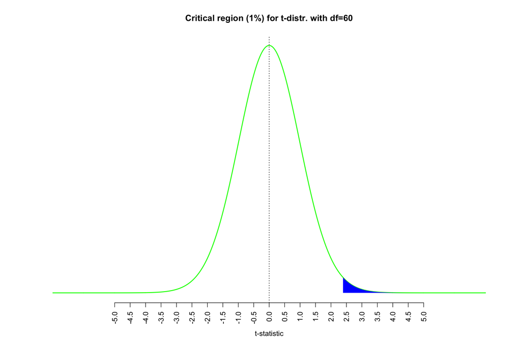

## Calculating t

Pooled variance via the $SD$ and $n$:

$s_{p}^2=\frac{df_1*s_{1}^2+df_2*s_{2}^2}{df_1 + df_2}$

$s_1^2 = 0.87^2 = 0.76$ and $s_2^2 = 1.72^2 = 2.96$

So:

$s_{p}^2=\frac{df_1*0.76+df_2*2.96}{df_1 + df_2}=\frac{49*0.76+49*2.96}{49 + 49}= 1.86$

## Calculating t

Estimated standard error:

$S_{M_1 - M_2} = \sqrt{{\frac{s^2_p}{n_1}+\frac{s^2_p}{n_2}}}=\sqrt{{\frac{1.86}{50}+\frac{1.86}{50}}} = 0.27$

*To be safe: always pool!*

## Calculating t

Getting to *t*:

$t=\frac{(M_1-M_2)-(\mu_1 - \mu_2)}{s_{(M_1-M_2)}}$

–>

$t=\frac{(6.95-7.19)-0}{0.27} = \frac{-0.24}{0.27} = -0.89$

*The sample difference is 0.89 times greater than expected if there were no difference.*

Note: this is actually not a lot.

## Locating t

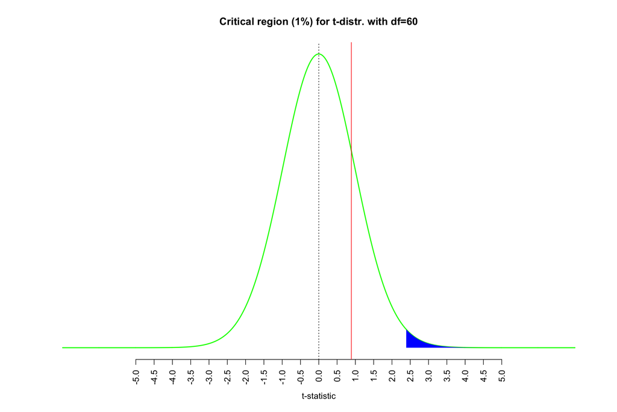

## Interpreting t

The sign of $t$ depends on the order of $M_1 - M_2$.

Always use the context here!

Our alternative (one-tailed) hypothesis was $H_1: \mu_1 < \mu_2$

Written differently: $H_1: \mu_1 - \mu_2 < 0$

## In the live sessions

- step-wise example
- assumption of homogeneity of variances

## Recap

- from the one-sample t-test to the independent t-test
- same logic as one-sample t-test with one exception: pooled variance
- idea of the pooled variance and formula
- logic of hypothesis testing the same

## Next week

- again: comparing two groups
- within-subjects design (also called repeated-measures design)